# Stats 101

technicalelvis.com

## Introduction to Probability Distributions

This document lists common probability distributions described in

- [Introduction to Probability by Joseph Blizstein and Jessica Hwang](https://drive.google.com/file/d/1VmkAAGOYCTORq1wxSQqy255qLJjTNvBI/view).
- [Little Inference Book by Brian Caffo](https://leanpub.com/LittleInferenceBook)

For each distribution, we show both the *probability density* and *cumulative distribution* plots.

**Probability density** plots show the probability that a random variable $X$ equals some value $x$; expressed using the notation: $P(X=x)$.

**Cumulative distribution** plots show the probablity that a random variable $X$ *is less than or equal to* some value $x$; expressed using the notation $P(X<=x)$.

The cumulative distribution answers questions like:

- “probability a person’s height is **greater than** 4 feet”
- “probability a cookie has **less than** 10 chocolate chips”
- “probability a shopping cart has **greater than** 3 items”.

The **emphasized** phrases indicate we want the total population with a value in a certain range. This contrasts with probability density, that answers questions like:

- “probability a person’s height **exactly equals** 4 feet”
- “probability a cookie has **exactly** 10 chocolate chips”
- “probability a shopping cart has **exactly** 3 items”.

The **emphasized** phrases indicate we want the slice of the population that exactly equals a certain value.

### Setting lower.tail parameter in R

The `R` distribution functions (eg. pbinom, ppois, pnorm, etc.) have a `lower.tail` option to get the range above or below a threshold.

- Set `lower.tail = FALSE` to get the population percentage **above** a threshold.
- Set `lower.tail = TRUE` to get the population percentage **below** a threshold.

### Distribution vs Density

In general, the term `distribution` is used to describe statistics on discrete variables (eg. item counts, customer counts, etc). The `density` applies to continuous variables that can take any value from $-inf$ to $+inf$ (eg. heights, weights, etc. )

## Binomial

Suppose that *n* independent coin flips (ie. Bernoulli trials) are performed, each with the same success probability p. Let *X* be the number of HEADS (ie. successes). The distribution of X is called a *Binomial distribution*.

### Binomial Density

The plot shows the probability of getting *exactly* *x* HEADS in 10 biased coin flips where the probability of HEADS is 20%.

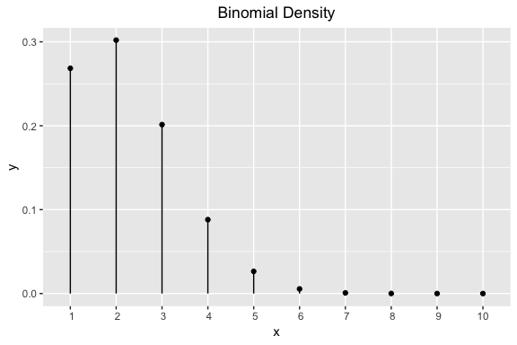

### Binomial Cumulative distribution

The plot shows the probability of getting greater than *x* HEADS in 10 coin flips where the probability of HEADS is 20%.

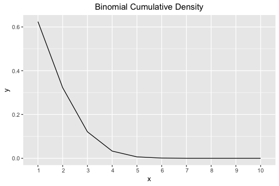

## Poisson

The Poisson distribution is often used in situations where we are counting the number of successes in a particular region or interval of time and there are a large number of trials. Each trial has a small probability of success. The parameter lambda ($\lambda$) is interpreted as the rate of occurrence of these rare events.

$\lambda$ could be 20 (emails per hour), 10 (chips per cookie), and 2 (earthquakes per year). The poisson paradigm says that in applications similar to the ones above, we can approximate the distribution of the number of events that occur by a Poisson Distribution.

### Poisson Density

Consider an example where the number of people that show up at a bus stop is Poisson with a mean of 2.5 per hour. If watching the bus stop for 1 hours, what is the probability that exactly $x$ people show up for the whole time?

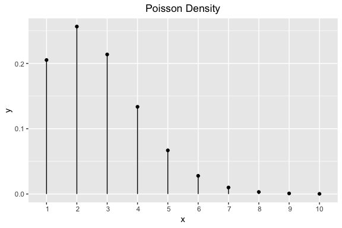

### Poisson Cumulative Distribution

For the previous example, what is the probability that more than $x$ people show up for the whole time?

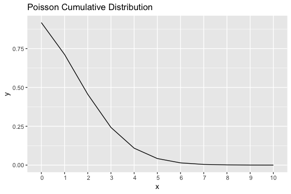

### Simulating a Poisson Process containing 1 event type

The following example illustrates how to simulate arrival times within a specified interval $(0,L]$.

1. Generate the number of arrivals $N(L)$ from $Pois(\lambda*L)$.
2. Conditional on $N(L) = n$, generate arrival times from ordered `Unif(O,L)`.

The following plot simulates arrivals from a Poisson process with rate 10 events/interval after observing for 5 intervals.

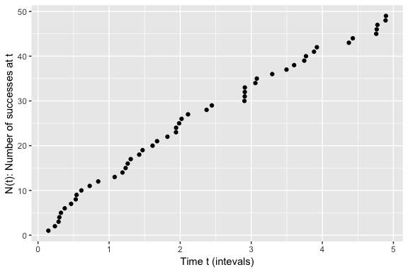

### Simulating a Poisson Process containing 2 event types

Now, let’s build on the previous example to model a Poisson process that contains 2 event types.

1. Generate the number of arrivals $N(L)$ from $Pois(\lambda*L)$.
2. Conditional on $N(L) = n$, generate arrival times from ordered `Unif(O,L)`.
3. For each arrival, we flip a coin with probability `Bern(0.3)` of Heads; these coin tosses are labeled as `type-1`; the rest are labeled as `type-2`.

The resulting vectors of arrival times t1 and t2 are realizations of 2 independent Poisson processes.

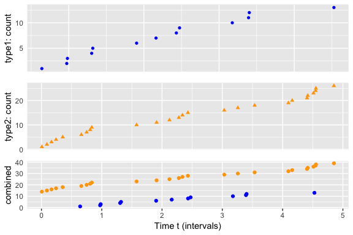

## Gaussian

The Normal distribution is a famous continuous distribution with a bell-shaped PDF. It is extremely widely used in statistics because of a theorem, the [central limit theorem](https://github.com/telvis07/StatsInf_PeerAssessment1/blob/master/project.md), which says under very weak assumptions, the sum of a large number of i.i.d. random variables has an approximately Normal distribution - regardless of the distribution of the underlying random variable.

The simplest normal distribution is the *standard normal*, which is centered at 0 and has a variance of 1.

### Gaussian Density

The following plot shows the probability that `Normal(0,1)` *exactly equals* any value between -3 and +3.

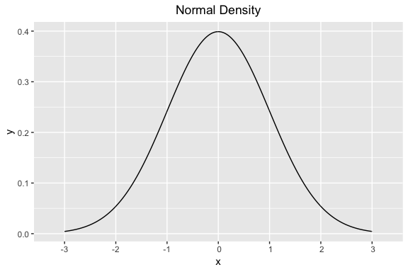

### Gaussian Cumulative Distribution

The following plot shows the probability that `Normal(0,1)` is *greater than* to any value between -3 and +3.

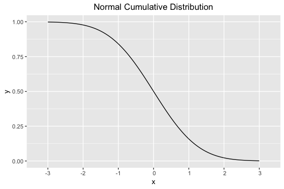

### Click Fraud Rate Simulation

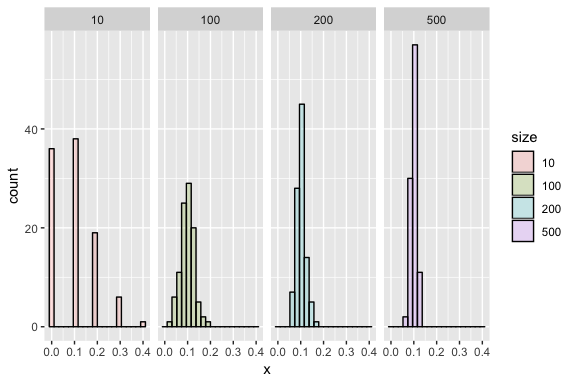

### Multivariate Normal

A multivariate (MVN) normal distribution generalizes the Normal distribution into higher dimension. The parameters of a multi-variate normal are:

1. The *mean vector* ($\mu_1, \mu_2, ... \mu_n$)
2. The *covariance matrix*, which is the *k x k* matrix of covariances between components, arranged so that the row *i*, column *j* entry is Cov($X_i, X_j$).

The following plot shows random variables from 2 bivariate normals: `BLUE` and `ORANGE`. The `BLUE` distribution has parameters $N((1,0)^T, I)$. The `ORANGE` distribution has parameters $N((0,1)^T, I)$. **I** represents a 2x2 identity matrix - where the diagonals are `1` and other values are `0`.

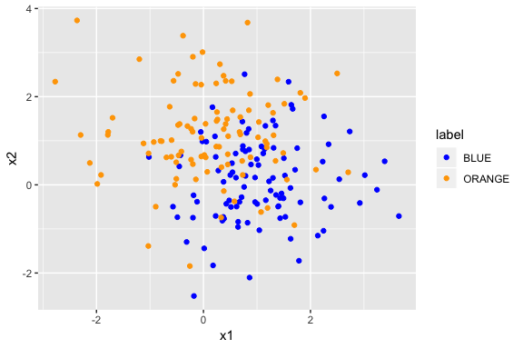